# Stroke Survival Analysis - 4 Data Analysis & Results

## K-M Plot

- The K-M plot can be interpreted as:
  - X-axis: represents time in days
  - Y-axis: provides the probability of participants having remained stroke free since the start of the study
  - The line represents the survival curve of the cohort of participants based on the survival object
  - The shaded area is the 95% confidence interval
  - A vertical drop in the line indicates an event
- Further interpretation can be noted as:
  - At time zero, the survival probability is 1.0 (100% of the participants are stroke free)
  - At time 2,500, the survival probability is .99 (99% of the participants are stroke free)
  - At time > 4,000 the the survival probability is < .98 (less than 98% of the participants are stroke free)

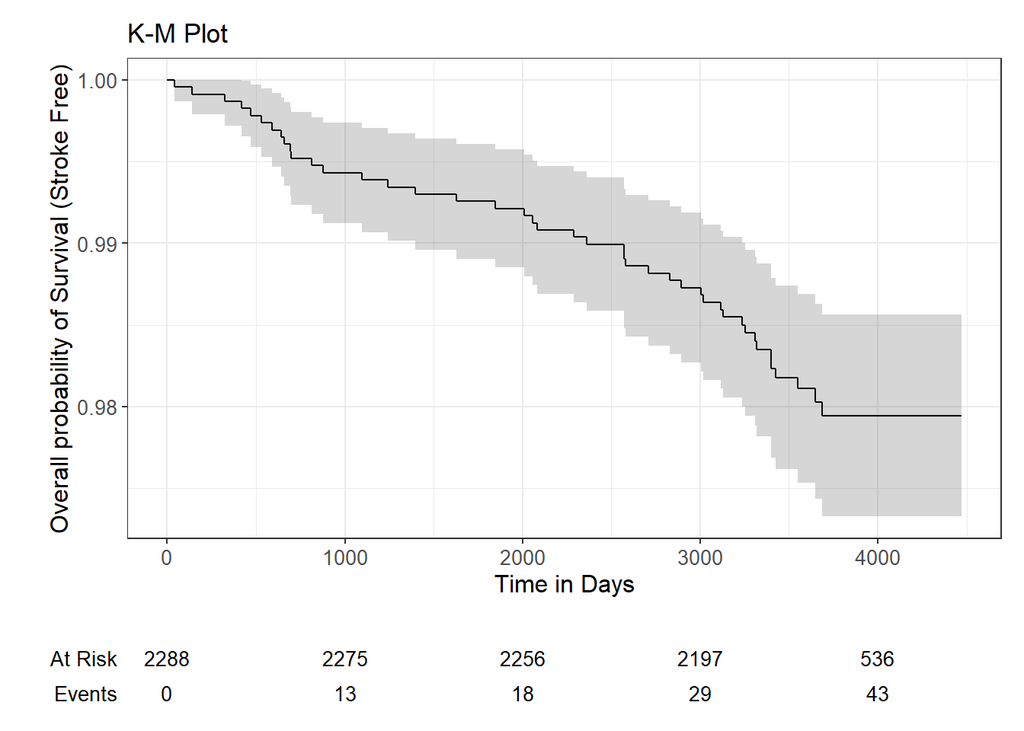

## Cox Proportion Hazards Model

The hazard object created is modeled on all variables that provides a table which includes the hazard ratio (HR), confidence interval and p-value. Of interest from the Cox regression is the HR (Zabor).

- The following HR values indicate:
  - HR < 1 indicates a reduced hazard of stroke
  - HR > 1 indicates an increased hazard of stroke

| **Characteristic** | **HR**<sup>1</sup> | **95% CI**<sup>1</sup> | **p-value** |
| --- | --- | --- | --- |
| Age in Years | 1.08 | 1.04, 1.12 | <0.001 |
| Hypertensive Status |  |  |  |
| Normal/Pre-Hypertensive | — | — |  |
| Hypertensive | 1.10 | 0.54, 2.23 | 0.8 |
| Diabetes Categorization |  |  |  |
| Non-Diabetic | — | — |  |
| Pre-Diabetic | 2.65 | 1.09, 6.44 | 0.031 |
| Diabetic | 4.82 | 1.89, 12.3 | 0.001 |
| Smoking Status |  |  |  |
| Current Smoker | — | — |  |
| Never Smoked/Quit >= 12 months | 0.37 | 0.17, 0.81 | 0.012 |
| AHA BMI Categorization |  |  |  |
| Obese | — | — |  |
| Overweight | 1.27 | 0.65, 2.47 | 0.5 |
| Normal Weight | 1.30 | 0.46, 3.67 | 0.6 |
| AHA Total Cholesterol Categorization |  |  |  |
| Poor Health | — | — |  |
| Intermediate Health | 0.69 | 0.32, 1.47 | 0.3 |
| Ideal Health | 0.50 | 0.21, 1.16 | 0.10 |

<sup>1</sup> HR = Hazard Ratio, CI = Confidence Interval

### 4.0.1 Hazard Ratio Interpretation

The JHS data is not consistent in the use of the healthy indicator as the reference. The below interpretation will be split by those with the healthy group as reference and those with the least healthy group as the reference. While the HR is the indicator of interest, p-values will be noted to indicate additional statistical significance to the model.

[output not shown]

### Hazard Curve

- The Cox PH Curve can be interpreted as:
  - X-axis: represents time in days
  - Y-axis: provides the probability of participants having a stroke since the start of the study
  - The line represents the hazard curve of the cohort of participants based on the survival object
  - The shaded area is the 95% confidence interval
  - A vertical climb in the line indicates an event
- Further interpretation can be noted as:
  - At time zero, the hazard probability is 0.0 (0% of the participants have had a stroke since joining the study)
  - At time 2,500, the hazard probability is .01 (1% of the participants have had a stroke since joining the study)
  - At time > 4,000 the the hazard probability is > .02 (greater than 2% of the participants have had a stroke since joining the study)

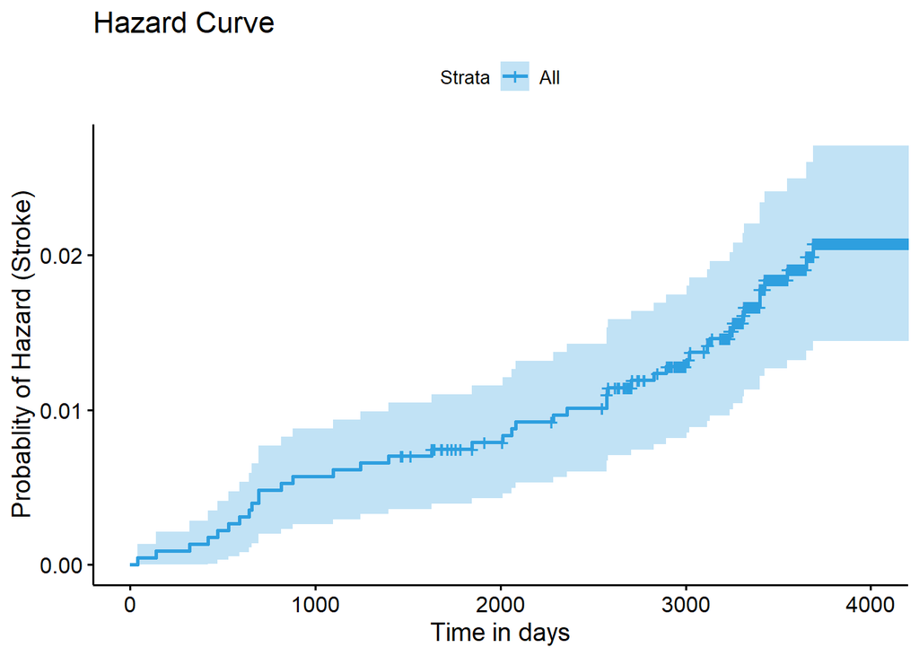